# Open Data Network Business Intelligence Report

Data-Driven Management Analysis

Pranshu Deora - 668148844

2025-11-19

# Section 1: Business Problem Definition and Context

Problem Statement: A real estate investment firm needs to identify the most promising Bay Area counties and census tracts for residential property development based on 2017 median household income patterns. The analysis will help target areas with optimal income levels that balance affordability with purchasing power, avoiding both low-income markets and ultra-high-income saturated areas. This dataset provides precise geographic income distribution essential for strategic property investment decisions.

# Section 2: Data Source Assessment

## 2(a) Data Source Documentation:

Direct URL: https://dev.socrata.com/foundry/data.bayareametro.gov/8bur-3axz

This dataset originates from the U.S. Census Bureau’s American Community Survey (ACS) 5-year estimates, accessed through the Bay Area Metro Data portal. The original purpose was governmental planning, resource allocation, and policy development based on comprehensive economic demographics. Data covers 2017 and is updated every 5 years through the ACS program. It encompasses the entire San Francisco Bay Area across 9 counties with census tract-level granularity, representing approximately 7 million residents. Data is collected through systematic household surveys with statistical sampling methodology. Key limitations include the 2017 vintage and margin of error estimates that should be considered in analysis.

## 2(b) Access Method Implementation:

Method 1: CSV Download from Open Data Network:

```r
# Load the dataset
income_data <- read.csv("C:/Users/C4S/Downloads/Test4Dataset.csv")
```

Explanation: CSV download was chosen for its simplicity and reliability, ensuring consistent offline analysis without API dependencies. This method provides stable data for reproducible business decision-making.

## 2(c) Data Quality Assessment:

```r
# Required data quality analysis
dim(income_data) # Verify rows > 500 and columns >= 5
```

```
## [1] 1588    6
```

```r
str(income_data) # Check variable types (numeric vs categorical)
```

```
## 'data.frame':    1588 obs. of  6 variables:
##  $ Residence_Geo                        : chr  "400,100" "400,200" "400,300" "400,400" ...
##  $ County                               : chr  "Alameda County" "Alameda County" "Alameda County" "Alameda County" ...
##  $ Year                                 : int  2017 2017 2017 2017 2017 2017 2017 2017 2017 2017 ...
##  $ Median_HH_Inc_PlaceOfResidence_IA    : chr  "208,393" "147,500" "88,173" "102,821" ...
##  $ Median_HH_Inc_PlaceOfResidence_IA_MOE: chr  "46,352" "34,827" "11,036" "13,517" ...
##  $ Source                               : chr  "ACS_B19013_5YR" "ACS_B19013_5YR" "ACS_B19013_5YR" "ACS_B19013_5YR" ...
```

```r
# Data completeness
colSums(is.na(income_data))
```

```
##                         Residence_Geo                                County
##                                     0                                     0
##                                  Year     Median_HH_Inc_PlaceOfResidence_IA
##                                     0                                     0
## Median_HH_Inc_PlaceOfResidence_IA_MOE                                Source
##                                     0                                     0
```

```r
# Percentage of missing values per column
(colSums(is.na(income_data)) / nrow(income_data)) * 100
```

```
##                         Residence_Geo                                County
##                                     0                                     0
##                                  Year     Median_HH_Inc_PlaceOfResidence_IA
##                                     0                                     0
## Median_HH_Inc_PlaceOfResidence_IA_MOE                                Source
##                                     0                                     0
```

```r
sapply(income_data, function(x) length(unique(x)))
```

```
##                         Residence_Geo                                County
##                                  1584                                     9
##                                  Year     Median_HH_Inc_PlaceOfResidence_IA
##                                     1                                  1535
## Median_HH_Inc_PlaceOfResidence_IA_MOE                                Source
##                                  1532                                     1
```

Quality Assessment Summary: The dataset demonstrates 100% data completeness with zero missing values across all 1,588 observations, making it fully usable for analysis. We can trust this source, beacuse this data comes from the U.S. Census Bureau, a highly trusted government agency with standardized collection methodologies and rigorous quality controls. This dataset specifically supports strategic residential development planning decisions by identifying optimal Bay Area locations based on census tract-level household income patterns.

# Section 3: Comprehensive Data Analysis

```r
# Data cleaning and preparation
# Convert income columns from character to numeric
income_data_clean <- income_data
income_data_clean$Median_HH_Inc_PlaceOfResidence_IA <- as.numeric(gsub(",", "",
                                                                     income_data_clean$Median_HH_Inc_PlaceOfResidence_IA))
income_data_clean$Median_HH_Inc_PlaceOfResidence_IA_MOE <- as.numeric(gsub(",", "",
                                                                         income_data_clean$Median_HH_Inc_PlaceOfResidence_IA_MOE))

# Remove any rows with NA values after conversion
income_data_clean <- income_data_clean[complete.cases(income_data_clean), ]

# Create income categories for analysis
income_data_clean$Income_Category <- cut(income_data_clean$Median_HH_Inc_PlaceOfResidence_IA,
                                       breaks = c(0, 50000, 100000, 150000, 200000, Inf),
                                       labels = c("Under $50K", "$50K-$100K", "$100K-$150K",
                                                "$150K-$200K", "Over $200K"))

cat("Data preparation complete. Final dataset dimensions:\n")
```

```
## Data preparation complete. Final dataset dimensions:
```

```r
dim(income_data_clean)
```

```
## [1] 1588    7
```

## 3(a) Descriptive Analytics:

Aggregate analysis 1: Average income by county

```r
county_income <- aggregate(Median_HH_Inc_PlaceOfResidence_IA ~ County,
                         data = income_data_clean,
                         FUN = mean)
county_income <- county_income[order(-county_income$Median_HH_Inc_PlaceOfResidence_IA), ]
names(county_income) <- c("County", "Average_Income")

cat("Average Household Income by County (Descending Order):\n")
```

```
## Average Household Income by County (Descending Order):
```

```r
print(county_income)
```

```
##                 County Average_Income
## 6     San Mateo County      118077.46
## 7   Santa Clara County      113485.47
## 3         Marin County      107420.18
## 2  Contra Costa County       97844.19
## 5 San Francisco County       97635.69
## 1       Alameda County       91861.61
## 4          Napa County       83863.60
## 9        Sonoma County       73255.28
## 8        Solano County       72472.57
```

Aggregate analysis 2: Income distribution by category using table

```r
income_distribution <- table(income_data_clean$Income_Category)
cat("\nIncome Category Distribution:\n")
```

```
##
## Income Category Distribution:
```

```r
print(income_distribution)
```

```
##
##  Under $50K  $50K-$100K $100K-$150K $150K-$200K  Over $200K
##         154         729         496         158          40
```

```r
cat("\nIncome Category Percentages:\n")
```

```
##
## Income Category Percentages:
```

```r
print(round(prop.table(income_distribution) * 100, 1))
```

```
##
##  Under $50K  $50K-$100K $100K-$150K $150K-$200K  Over $200K
##         9.8        46.2        31.5        10.0         2.5
```

Interpretation: The aggregate analysis reveals San Mateo County has the highest average household income ($118,077), while Solano County has the lowest ($72,473). The table function shows that 46.2% of census tracts fall in the $50K-$100K income range, indicating this is the most common income bracket across the Bay Area.

## 3(b) Professional Visual Analytics:

```r
# Load ggplot2
library(ggplot2)
```

Visualization 1: County income comparison (Bar Chart)

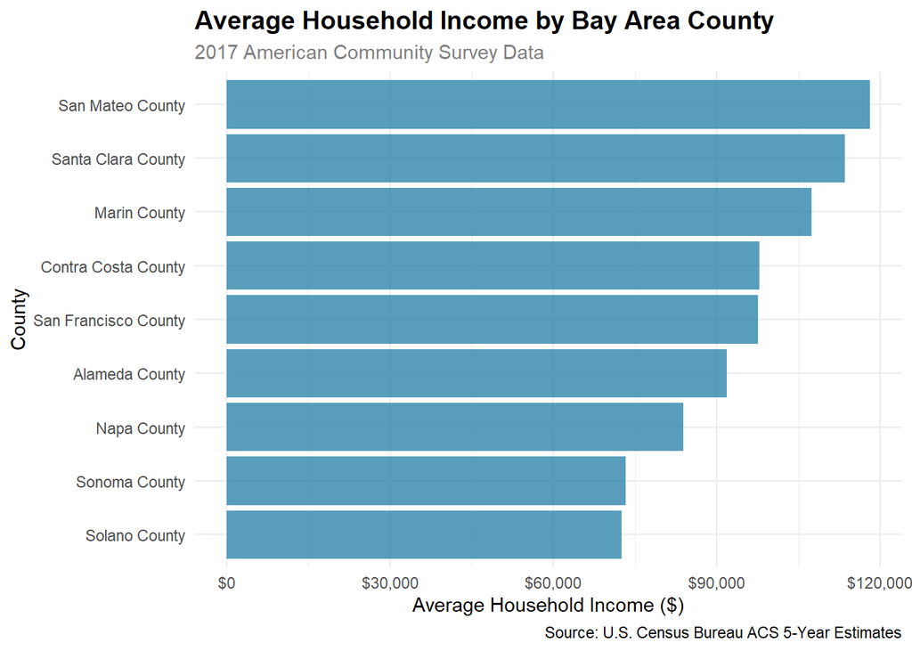

```r
ggplot(county_income, aes(x = reorder(County, Average_Income), y = Average_Income)) +
  geom_col(fill = "#2E86AB", alpha = 0.8) +
  coord_flip() +
  labs(
    title = "Average Household Income by Bay Area County",
    subtitle = "2017 American Community Survey Data",
    x = "County",
    y = "Average Household Income ($)",
    caption = "Source: U.S. Census Bureau ACS 5-Year Estimates"
  ) +
  theme_minimal() +
  scale_y_continuous(labels = scales::dollar_format()) +
  theme(
    plot.title = element_text(size = 14, face = "bold"),
    plot.subtitle = element_text(size = 11, color = "gray50")
  )
```

Visualization 2: Income distribution (Histogram)

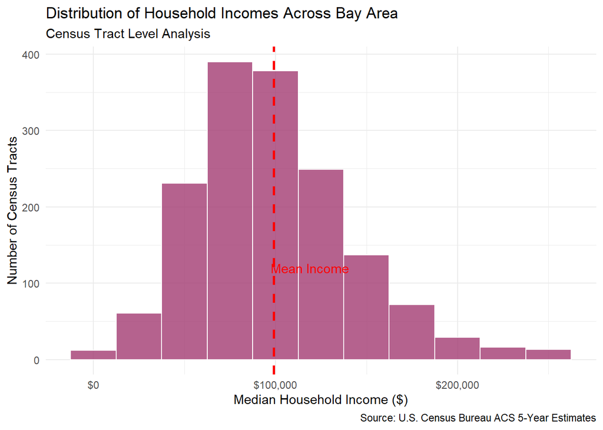

```r
ggplot(income_data_clean, aes(x = Median_HH_Inc_PlaceOfResidence_IA)) +
  geom_histogram(binwidth = 25000, fill = "#A23B72", alpha = 0.8, color = "white") +
  labs(
    title = "Distribution of Household Incomes Across Bay Area",
    subtitle = "Census Tract Level Analysis",
    x = "Median Household Income ($)",
    y = "Number of Census Tracts",
    caption = "Source: U.S. Census Bureau ACS 5-Year Estimates"
  ) +
  theme_minimal() +
  scale_x_continuous(labels = scales::dollar_format()) +
  geom_vline(aes(xintercept = mean(Median_HH_Inc_PlaceOfResidence_IA)),
             color = "red", linetype = "dashed", size = 1) +
  annotate("text", x = mean(income_data_clean$Median_HH_Inc_PlaceOfResidence_IA) + 20000,
           y = 120, label = "Mean Income", color = "red")
```

Visualization 3: Income category distribution (Pie Chart)

```r
# Load required packages
library(dplyr)
```

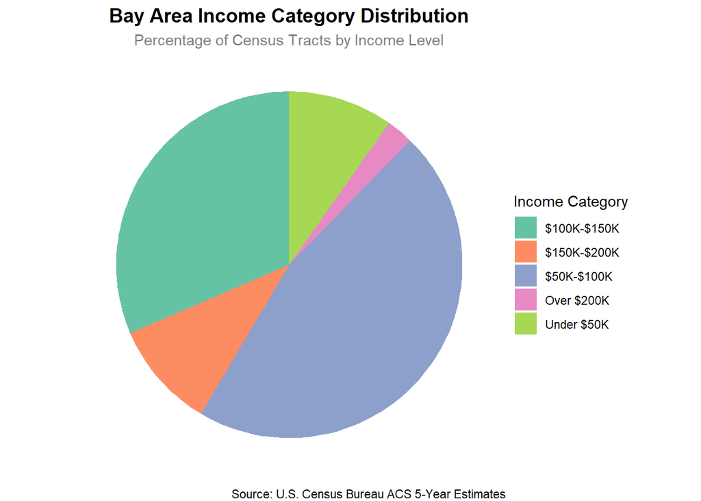

```r
library(ggplot2)

# Create the summary data using base R (no dplyr pipes)
income_counts <- table(income_data_clean$Income_Category)
income_summary <- data.frame(
  Income_Category = names(income_counts),
  Count = as.numeric(income_counts),
  Percentage = as.numeric(income_counts) / sum(income_counts) * 100
)

# Create the pie chart
ggplot(income_summary, aes(x = "", y = Count, fill = Income_Category)) +
  geom_bar(stat = "identity", width = 1) +
  coord_polar("y", start = 0) +
  labs(
    title = "Bay Area Income Category Distribution",
    subtitle = "Percentage of Census Tracts by Income Level",
    fill = "Income Category",
    caption = "Source: U.S. Census Bureau ACS 5-Year Estimates"
  ) +
  theme_void() +
  theme(
    plot.title = element_text(size = 14, face = "bold", hjust = 0.5),
    plot.subtitle = element_text(size = 11, color = "gray50", hjust = 0.5),
    legend.position = "right"
  ) +
  scale_fill_brewer(palette = "Set2")
```

## 3(c) Pattern Recognition:

Pattern 1: Income variability within counties

```r
county_variability <- income_data_clean %>%
  group_by(County) %>%
  summarise(
    Avg_Income = mean(Median_HH_Inc_PlaceOfResidence_IA),
    Income_Range = max(Median_HH_Inc_PlaceOfResidence_IA) - min(Median_HH_Inc_PlaceOfResidence_IA),
    Coefficient_of_Variation = sd(Median_HH_Inc_PlaceOfResidence_IA) / mean(Median_HH_Inc_PlaceOfResidence_IA)
  ) %>%
  arrange(desc(Income_Range))

cat("Income Variability Within Counties:\n")
```

```
## Income Variability Within Counties:
```

```r
print(county_variability)
```

```
## # A tibble: 9 × 4
##   County               Avg_Income Income_Range Coefficient_of_Variation
##   <chr>                     <dbl>        <dbl>                    <dbl>
## 1 Alameda County           91862.       250001                    0.459
## 2 San Mateo County        118077.       250001                    0.402
## 3 Contra Costa County      97844.       241552                    0.456
## 4 Santa Clara County      113485.       228093                    0.380
## 5 Marin County            107420.       213000                    0.409
## 6 San Francisco County     97636.       195375                    0.421
## 7 Solano County            72473.       155603                    0.389
## 8 Sonoma County            73255.       130652                    0.268
## 9 Napa County              83864.       112638                    0.289
```

Pattern 2: High-income concentration

```r
high_income_tracts <- income_data_clean %>%
  filter(Median_HH_Inc_PlaceOfResidence_IA > 200000) %>%
  group_by(County) %>%
  summarise(High_Income_Tracts = n()) %>%
  arrange(desc(High_Income_Tracts))

cat("\nHigh-Income Tract Concentration (>$200K):\n")
```

```
##
## High-Income Tract Concentration (>$200K):
```

```r
print(high_income_tracts)
```

```
## # A tibble: 5 × 2
##   County              High_Income_Tracts
##   <chr>                            <int>
## 1 Santa Clara County                  14
## 2 San Mateo County                    12
## 3 Contra Costa County                  7
## 4 Alameda County                       5
## 5 Marin County                         2
```

Pattern Descriptions:

Significant Within-County Income Inequality: All counties show substantial income ranges (over $100,000 difference between highest and lowest tracts). This indicates diverse neighborhood economic profiles within each county.

High-Income Concentration in Tech Hubs: Santa Clara County (Silicon Valley) dominates high-income tracts with 14 areas exceeding $200,000 median income, followed by San Mateo County with 12. This pattern highlights the geographic concentration of wealth in technology-centric regions.

# Section 4: Strategic Recommendations:

Key Findings Summary:

1. Clear County Hierarchy Exists: San Mateo County ($118,077) and Santa Clara County ($113,485) demonstrate significantly higher average incomes than other Bay Area counties, establishing them as premium markets for high-end residential development targeting affluent buyers.
2. Middle-Income Dominance: 77.7% of census tracts fall between $50,000-$150,000 income range, representing the largest addressable market segment. This suggests substantial opportunity for mid-market housing developments that balance affordability with adequate purchasing power.
3. Concentrated Wealth Patterns: High-income households (>$200,000) are heavily concentrated in specific counties, with Santa Clara containing 14 high-income tracts compared to zero in Sonoma County. This indicates targeted opportunities for luxury developments in wealth-concentrated areas while avoiding oversaturated markets.